# Report 6

Advay Vyas

February 26, 2026

# Introduction

This week, I will save a CSV file of all metrics, create scatter plots comparing ground-truth to metrics for time and magnitude, and then find the metrics that perform best for each category (timing & magnitude) and maybe some additional metrics that describe curve differences as a whole well.

# Data processing

## Metric functions

```r
source("../metric_functions.R")
source("../graphstat_functions.R")
source("../write_dtw.R")
```

## Datasets

```r
hsa_state = read.csv("../hsa_state_inc.csv")
dtw_results = read_csv("../all_dtw_results.csv")
hsa_dtw = dtw_results |>
    left_join(hsa_state, by = join_by(ID == hsa_nci_id))
write_csv(unique(hsa_dtw), "../hsa_vs_state_metrics.csv")
```

```r
all_metrics = read_csv("../hsa_vs_state_metrics.csv")
```

# Scatter plots

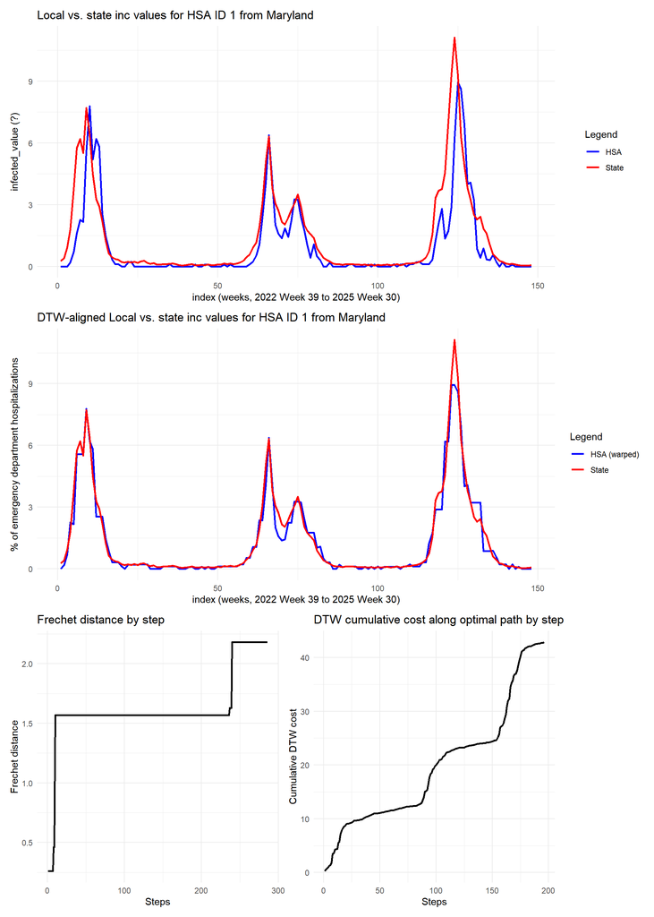

```r
# set.seed(77)
id_list = hsa_state$hsa_nci_id
id = sample(id_list, 1)
graph_hsa(hsa_id = 1)  # currently fixed at 1
```

```r
# knitr::kable(dtw_stats(hsa_id = id), digits = 3)
```

## Finding the ground truth

The truth_diff values are **always** HSA - state. A positive time difference means that the HSA has a later peak and a positive magnitude difference means that the HSA has a larger peak.

```r
all_metrics_modified = all_metrics |>
  mutate(week_index = (epi_week + (epi_year - 2022) * 52 - 38),
    peak_window = case_when(
      week_index <= 50  ~ 1,
      week_index <= 100 ~ 2,
      TRUE              ~ 3
  ))

truth_peaks =
  all_metrics_modified |>
  group_by(ID, state, peak_window) |>
  summarise(
    # HSA peak
    hsa_peak_week  = week_index[which.max(inc_hsa)],
    hsa_peak_value = max(inc_hsa, na.rm = TRUE),

    # State peak
    state_peak_week  = week_index[which.max(inc_state)],
    state_peak_value = max(inc_state, na.rm = TRUE),

    # Differences
    truth_time_diff = hsa_peak_week - state_peak_week,
    truth_time_diff_abs = abs(truth_time_diff),
    truth_mag_ratio  = hsa_peak_value / state_peak_value,

    .groups = "drop"
  )

metrics_unique =
  all_metrics_modified |>
  group_by(ID, state) |>
  filter(week_index == 2) |>
  summarise(
    mean_abs_lag,
    signed_lag,
    lag_sd,
    dtw_mae,
    dtw_rmse,
    rmse,
    amp_ratio,
    dtw_amp_ratio,
    lag_amp_corr,
    frechet,
    .groups = "drop"
  )

diff_peak_data =
  truth_peaks |> left_join(metrics_unique,
            by = c("ID", "state"))

glimpse(diff_peak_data)
```

```
## Rows: 2,013
## Columns: 20
## $ ID                  <dbl> 1, 1, 1, 2, 2, 2, 3, 3, 3, 4, 4, 4, 5, 5, 5, 7, 7,…
## $ state               <chr> "Maryland", "Maryland", "Maryland", "Kentucky", "K…
## $ peak_window         <dbl> 1, 2, 3, 1, 2, 3, 1, 2, 3, 1, 2, 3, 1, 2, 3, 1, 2,…
## $ hsa_peak_week       <dbl> 10, 66, 125, 9, 74, 125, 9, 66, 125, 10, 75, 124, …
## $ hsa_peak_value      <dbl> 7.78, 6.37, 8.94, 12.09, 8.08, 10.09, 8.71, 6.52, …
## $ state_peak_week     <dbl> 9, 66, 124, 9, 66, 124, 9, 66, 124, 10, 66, 124, 9…
## $ state_peak_value    <dbl> 7.70, 6.31, 11.12, 13.19, 5.69, 14.00, 8.35, 5.78,…
## $ truth_time_diff     <dbl> 1, 0, 1, 0, 8, 1, 0, 0, 1, 0, 9, 0, 0, 0, -2, -3, …
## $ truth_time_diff_abs <dbl> 1, 0, 1, 0, 8, 1, 0, 0, 1, 0, 9, 0, 0, 0, 2, 3, 0,…
## $ truth_mag_ratio     <dbl> 1.0103896, 1.0095087, 0.8039568, 0.9166035, 1.4200…
## $ mean_abs_lag        <dbl> 2.489796, 2.489796, 2.489796, 4.985981, 4.985981, …
## $ signed_lag          <dbl> -0.96938776, -0.96938776, -0.96938776, 0.78971963,…
## $ lag_sd              <dbl> 3.139342, 3.139342, 3.139342, 7.084181, 7.084181, …
## $ dtw_mae             <dbl> 0.21852041, 0.21852041, 0.21852041, 0.21415888, 0.…
## $ dtw_rmse            <dbl> 0.4019144, 0.4019144, 0.4019144, 0.5216047, 0.5216…
## $ rmse                <dbl> 1.2379713, 1.2379713, 1.2379713, 0.9337027, 0.9337…
## $ amp_ratio           <dbl> 0.2757365, 0.2757365, 0.2757365, 0.4859459, 0.4859…
## $ dtw_amp_ratio       <dbl> 0.8155707, 0.8155707, 0.8155707, 0.8823529, 0.8823…
## $ lag_amp_corr        <dbl> -0.20089049, -0.20089049, -0.20089049, -0.27579822…
## $ frechet             <dbl> 2.18, 2.18, 2.18, 3.91, 3.91, 3.91, 2.23, 2.23, 2.…
```

## Time metrics vs. truth

```r
abs_time_summary = diff_peak_data |>
    group_by(ID, state) |>
    summarise(sum_abs_diff = sum(abs(truth_time_diff), na.rm = TRUE),
        .groups = "drop")

diff_peak_time = diff_peak_data |>
    left_join(abs_time_summary)
```

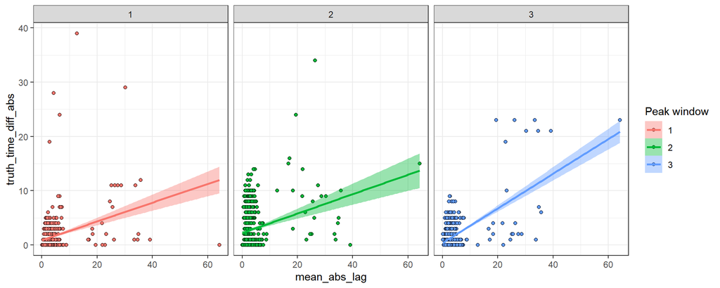

```r
# ggplot(diff_peak_time, aes(x = signed_lag, y =
# truth_time_diff)) + geom_point()

ggplot(diff_peak_time, aes(x = mean_abs_lag, y = truth_time_diff_abs,
    fill = as.factor(peak_window))) + geom_point(pch = 21, color = "black") +
    geom_smooth(method = "lm", aes(color = as.factor(peak_window))) +
    facet_wrap(~peak_window) + theme_bw() + labs(fill = "Peak window",
    color = "Peak window")
```

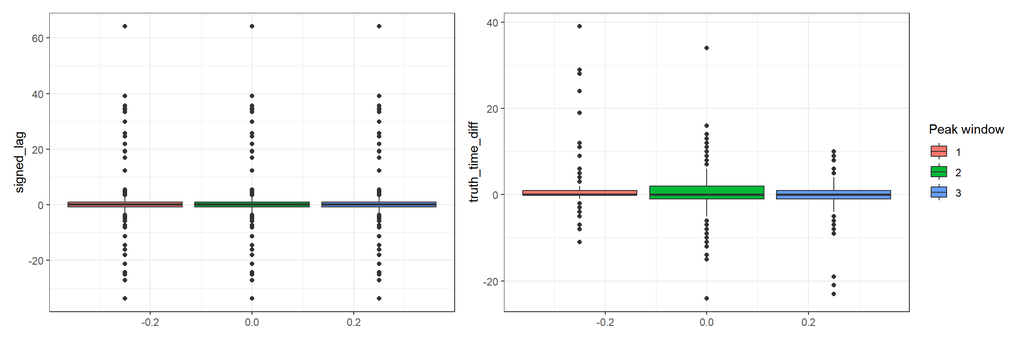

```r
(ggplot(diff_peak_time, aes(fill = as.factor(peak_window))) +
    geom_boxplot(aes(y = signed_lag)) + theme_bw() + labs(fill = "Peak window") +
    theme(legend.position = "none")) + (ggplot(diff_peak_time,
    aes(fill = as.factor(peak_window))) + geom_boxplot(aes(y = truth_time_diff)) +
    theme_bw() + labs(fill = "Peak window"))
```

```r
timing_cor_table = diff_peak_time |>
    group_by(peak_window) |>
    summarise(cor_mean_abs_lag = cor(truth_time_diff_abs, mean_abs_lag,
        use = "complete.obs"), cor_signed_lag = cor(truth_time_diff_abs,
        signed_lag, use = "complete.obs"), cor_lag_sd = cor(truth_time_diff_abs,
        lag_sd, use = "complete.obs"), cor_frechet = cor(truth_time_diff_abs,
        frechet, use = "complete.obs"), .groups = "drop")
timing_cor_table
```

```
## # A tibble: 3 × 5
##   peak_window cor_mean_abs_lag cor_signed_lag cor_lag_sd cor_frechet
##         <dbl>            <dbl>          <dbl>      <dbl>       <dbl>
## 1           1            0.310        -0.0558      0.328      0.157
## 2           2            0.251         0.141       0.241      0.140
## 3           3            0.585         0.535       0.481      0.0616
```

Time metrics are not very good but I think the bulk of the blame can be attributable to the lack of splitting per window, where we can see there might be a good bit of variation. More importantly, I think there’s too much noise in DTW to understand the lag clearly and forecast what the peak difference will be because of how finicky the DTW can be.